# 第13回 その差は、偶然でも出るか

並べ替え検定とブートストラップ

# 導入

## 前回：シードで、数が揺れた

① 場面●○○○○○○

- 前回は、論文の著者のコードを動かし、論文の数を出し直した
- Affinity Propagationのグループの数は、乱数のシードを決めないと、実行のたびに揺れた

## 結果は、ほかの理由でも揺れる

① 場面●●○○○○○

- 誰がデータに入ったかでも、計算の結果は揺れる
- 手元のデータで見えた差は、偶然でも出る程度のものか
- どれくらいの幅で揺れるのか

## 場面：職業訓練の評価担当

① 場面●●●○○○○

- あなたは、職業訓練事業の評価担当
- 仕事に就けずにいる人に、しばらく仕事の経験を積んでもらう事業

## 続けるかを決めたい

① 場面●●●●○○○

- 費用がかかる事業なので、続けるかどうかを決めたい
- そのために、訓練で収入が増えたのかを報告する

## 多ければ、訓練のおかげ？

① 場面●●●●●○○

- 訓練を受けた人の収入が多くても、訓練のおかげとは限らない
- もともと働く意欲の高い人が、訓練を受けたのかもしれない

## くじ引きで分けた

① 場面●●●●●●○

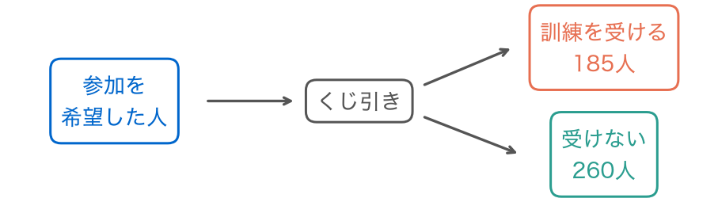

- 参加を希望した人を、くじ引きで2つの群に分けた

## 決めたいこと

① 場面●●●●●●●

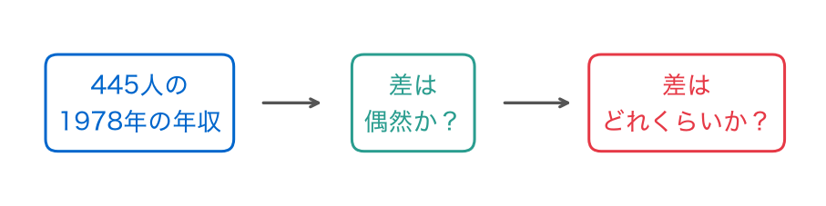

- 訓練に効果があったと報告してよいか。あったなら、どれくらいか

## 手元のデータ

② 手元のデータ●○○

- 1970年代のアメリカの職業訓練の実験（National Supported Work Demonstration）
- LaLonde（1986）が分析し、Dehejia & Wahba（1999）が445人に絞った
- Rajeev Dehejiaのページで公開されている

## 1行が1人

② 手元のデータ●●○

- くじで訓練を受けた185人と、受けなかった260人
- 答えの列は、訓練が終わったあとの1978年の年収（ドル）
- 訓練の前の1975年の年収や、年齢・教育年数も並ぶ

## データをのぞく

② 手元のデータ●●●

```
   treat  age  educ  black  hispanic  married  nodegree  re74  re75      re78
0      1   37    11      1         0        1         1   0.0   0.0   9930.05
1      1   22     9      0         1        0         1   0.0   0.0   3595.89
2      1   30    12      1         0        0         0   0.0   0.0  24909.45
(445, 10)
```

- `treat`が1なら訓練を受けた人、`re78`が1978年の年収

## 最後に出す答え

③ 今日の問い●○

- 訓練を受けた人と受けなかった人の、年収の差
- その差が偶然でも出るかを表す、p値
- 差がどれくらいの幅で揺れるかを表す、区間

## 今日の問い

③ 今日の問い●●

職業訓練を受けた人は、受けなかった人より収入が多くなったと言えるか？ 多いなら、どれくらいか？

## もう1つのねらい：ためて読む

④ もう1つのねらい●○

- 乱数でデータを作り直す計算を何千回もくり返し、結果をリストにためて、分布として読めるようになる

## 式ではなく、くり返しで

④ もう1つのねらい●●

- 「偶然ならどれくらいの差が出るか」を、式で求めずに、乱数で作って数える
- 1万回くり返して、結果を`for`と`append`でためる
- 同じ手順を2回目に使うときは、`def`にまとめる

## 今日の道筋

⑤ 今日の問い●

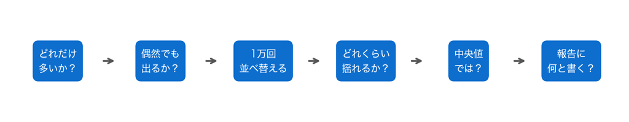

- 6つの小さな問いに答えていく

# 0. 準備

## まずは道具

- 第13回のノートを開き、上から順にセルを実行する
- 道具を呼び出し、データの置き場所を決める

## お手本：道具を呼び出す

0節 ① 道具●○

```python
import numpy as np
import pandas as pd
import matplotlib.pyplot as plt
```

- 今日は、numpy・pandas・matplotlibの3つだけ
- 検定や区間も、この3つで書く

## データの置き場所

0節 ① 道具●●

```python
# データはこのリポジトリから読み込む
DATA_DIR = ('https://raw.githubusercontent.com/k0heiun0/'
            'applied_exercise_preview/main/shared/data')
```

- 職業訓練のファイル（`nsw.csv`）は、この置き場所にある

## やってみよう：0節

0節 ② 確かめる●

- 0節のセルを上から実行する

動画の人は、ここで一時停止。

# 1. 訓練を受けた人の年収は、どれだけ多いか？

## まず、差を出す

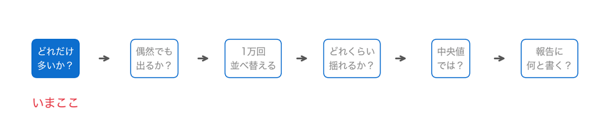

- 準備ができた。まず、2つの群の年収を比べる

## お手本：データを読む

1節 ① 読む●○○○

```python
d = pd.read_csv(f'{DATA_DIR}/nsw.csv')
d = d.rename(columns={'treat': '訓練', 'age': '年齢',
                      'educ': '教育年数', 'nodegree': '高卒資格なし',
                      're75': '年収75', 're78': '年収78'})
cols = ['訓練', '年齢', '教育年数', '高卒資格なし',
        '年収75', '年収78']
print(d.shape)
d[cols].head(3)
```

## 列の意味

1節 ① 読む●●○○

- `訓練`：訓練を受けた人が1、受けなかった人が0
- `高卒資格なし`：高校を卒業していない人が1
- `年収75`・`年収78`：1975年（訓練の前）と1978年（訓練のあと）の年収

## 445人

1節 ① 読む●●●○

```
(445, 10)
   訓練  年齢  教育年数  高卒資格なし  年収75      年収78
0   1  37    11       1   0.0   9930.05
1   1  22     9       1   0.0   3595.89
2   1  30    12       0   0.0  24909.45
```

- 1行が1人。10列のうち、6列を日本語の名前にした

## 変えてみる：群の人数

1節 ① 読む●●●●

```python
d['訓練'].value_counts()
```

```
訓練
0    260
1    185
```

- 訓練を受けた人が185人、受けなかった人が260人

## お手本：群ごとの年収

1節 ② 群ごと●○○○

```python
d.groupby('訓練')['年収78'].agg(['mean', 'median']).round(1)
```

- `groupby('訓練')`で群に分け、`agg`で平均と中央値を出す（第1回）

## 平均も中央値も、受けた人が多い

1節 ② 群ごと●●○○

```
      mean  median
訓練
0   4554.8  3138.8
1   6349.1  4232.3
```

- 平均は6349.1ドルと4554.8ドル
- 中央値は4232.3ドルと3138.8ドル

## お手本：平均の差

1節 ② 群ごと●●●○

```python
m = d.groupby('訓練')['年収78'].mean()
print(round(m[1] - m[0], 1))
```

```
1794.3
```

- `m[1]`が受けた人、`m[0]`が受けなかった人の平均

## 差は1794.3ドル

1節 ② 群ごと●●●●

- 訓練を受けた人の年収の平均は、1794.3ドル多い
- 今日は、この差を、くり返しの計算で確かめていく

## お手本：年収の分布

1節 ③ 分布●○○○○○

```python
bins = range(0, 62001, 2000)
for g, lab in [(0, '受けなかった'), (1, '受けた')]:
    plt.hist(d.loc[d['訓練'] == g, '年収78'], bins=bins,
             alpha=0.5, label=lab)
plt.xlabel('1978年の年収（ドル）')
plt.ylabel('人数')
plt.legend()
plt.show()
```

## 1行ずつ読む

1節 ③ 分布●●○○○○

- `bins`：棒の区切り。0ドルから2000ドルきざみ
- `for g, lab in [...]`：群の番号と名前の組を、1つずつ取り出す
- `alpha=0.5`：半透明にして、重なりを見えるようにする

1節 ③ 分布●●●○○○

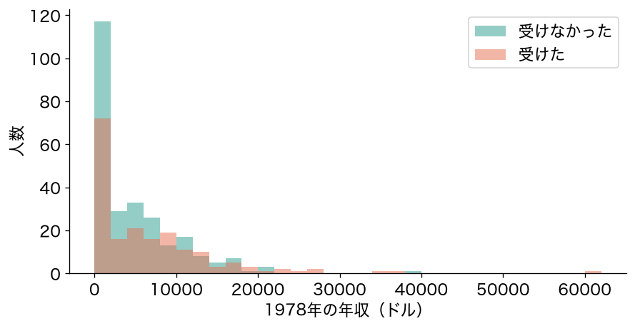

## 0ドルの人が多い

1節 ③ 分布●●●●○○

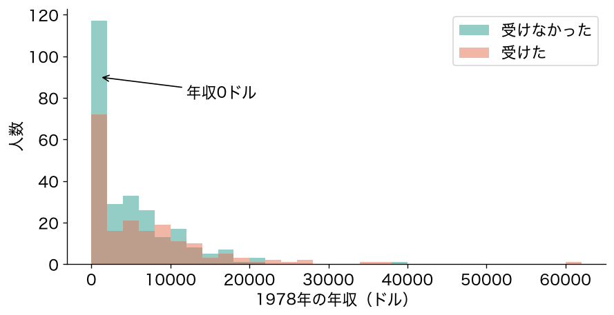

- どちらの群も、0ドルのあたりに人が多い
- 右へは、長く裾を引いている

## お手本：年収0ドルの割合

1節 ③ 分布●●●●●○

```python
d['無収入'] = d['年収78'] == 0
d.groupby('訓練')['無収入'].mean().round(3)
```

- `d['年収78'] == 0`で、年収が0ドルなら`True`の列を作る
- `True`の平均は、`True`の割合になる

## 収入の無い人が少ない

1節 ③ 分布●●●●●●

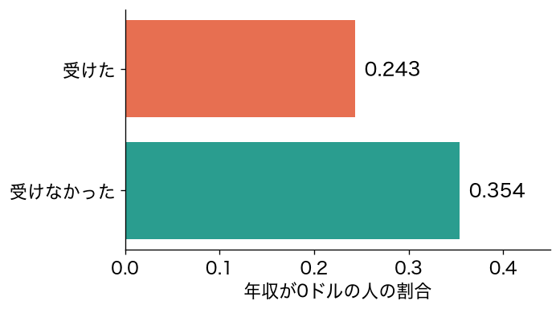

- 年収0ドルの人は、受けた人で24.3%、受けなかった人で35.4%

## くじ引きで、そろったか？

1節 ④ そろったか●○○○

- くじ引きで分けたなら、訓練の前の性質はおおむねそろうはず
- そろっていれば、1978年の年収の差は、訓練のせいと考えられる

## お手本：訓練の前の性質

1節 ④ そろったか●●○○

```python
before = ['年齢', '教育年数', '高卒資格なし', '年収75']
d.groupby('訓練')[before].mean().round(2)
```

```
       年齢   教育年数  高卒資格なし     年収75
訓練
0   25.05  10.09    0.83  1266.91
1   25.82  10.35    0.71  1532.06
```

## ほぼそろう、少しずれる

1節 ④ そろったか●●●○

- 年齢は25.05歳と25.82歳、教育年数は10.09年と10.35年
- 高卒資格なしの割合は0.83と0.71で、少しずれる
- くじ引きでも、偶然のずれは少し出る

## 差も、偶然のずれ？

1節 ④ そろったか●●●●

- 訓練の前の性質にも、偶然のずれが出た
- では、1978年の年収の差1794.3ドルも、偶然のずれではないか

## やってみよう：1節

1節 ⑤ 確かめる●

- 1節のお手本を上から実行する
- `agg`の中に`'max'`を足して、群ごとの最大の年収も見てみる

動画の人は、ここで一時停止。

# 2. 偶然でも、この差は出るか？

## 偶然のずれと、どう見分ける？

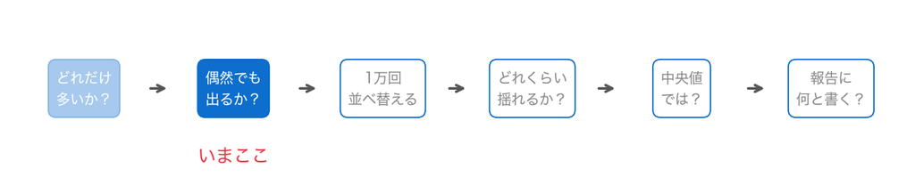

- 差は1794.3ドル。けれども、くじ引きでも偶然のずれは出る
- この差は、偶然でも出る程度のものか

## まず、効果はないと仮に考える

2節 ① 帰無仮説●○○

- 確かめたいこと：訓練に効果がある
- それを打ち消した仮説：訓練に効果はない
- 確かめたいことを打ち消した仮説を、帰無仮説と呼ぶ

## 効果がないなら、年収は同じ

2節 ① 帰無仮説●●○

- 効果がないなら、1人1人の1978年の年収は、くじに当たっても外れても同じ
- 平均の差は、くじで誰がどちらに入ったかだけで決まる

## くじを、引き直せばよい

2節 ① 帰無仮説●●●

- くじを引き直す（ラベルを並べ替える）と、差は変わる
- 引き直したときの差を見れば、「偶然でこれくらいの差は出る」という幅が分かる

## 6人で描く

2節 ② 並べ替える●○○○

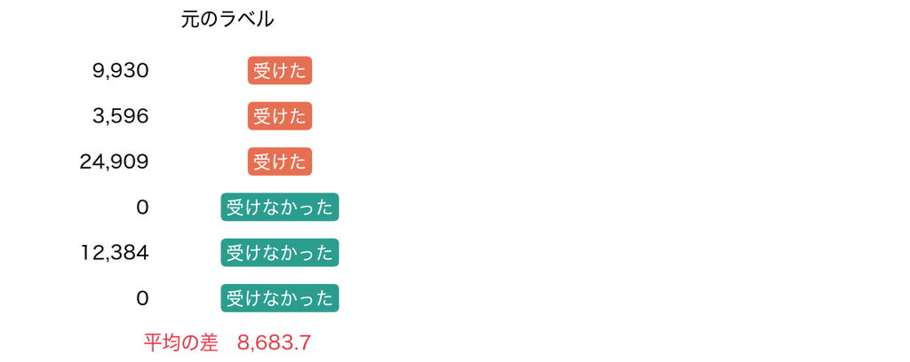

- 訓練を受けた3人と、受けなかった3人の、1978年の年収

## ラベルだけを入れ替える

2節 ② 並べ替える●●○○

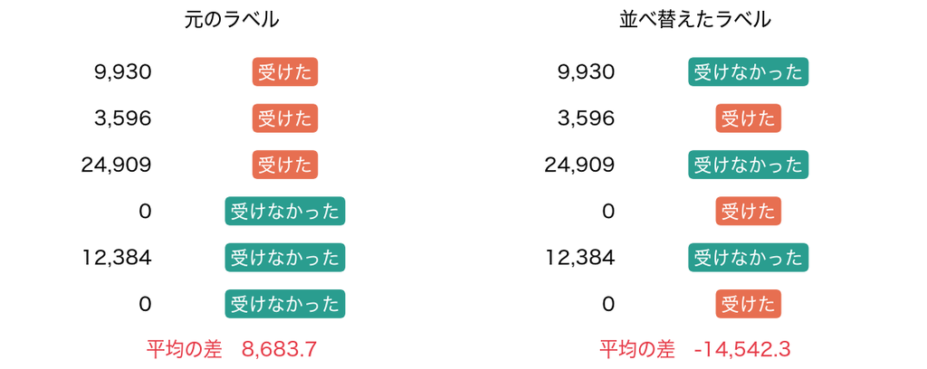

- 年収の列はそのまま。ラベルだけを並べ替える

## 並べ替えても、3人ずつ

2節 ② 並べ替える●●●○

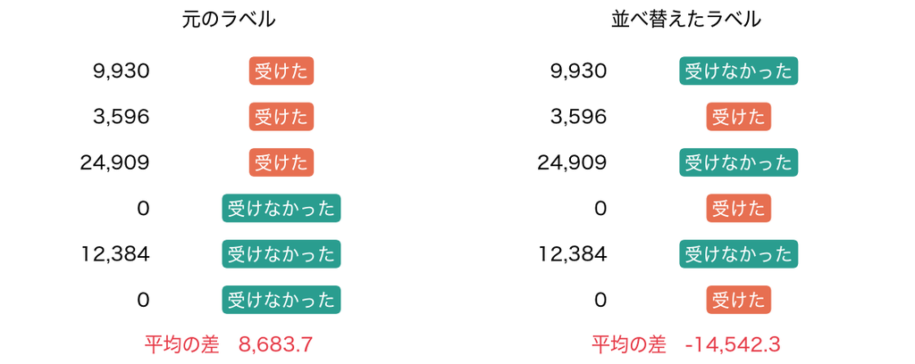

- 受けた人の数（3人）は変わらない
- 平均の差は、並べ替えると変わる

## 名前：並べ替え検定

2節 ② 並べ替える●●●●

- ラベルを何回も並べ替え、そのたびの差の分布を作る
- 観測した差が、その分布の中でどれくらい珍しいかを見る
- この確かめ方を、並べ替え検定と呼ぶ

## 新しい書き方：乱数で並べ替える

2節 ③ 乱数●○

```python
rng = np.random.default_rng(0)
print(rng.permutation([1, 1, 1, 0, 0, 0]))
```

```
[0 1 0 0 1 1]
```

- 1が3個、0が3個のまま、並びだけが変わった

## 1行ずつ読む

2節 ③ 乱数●●

- `np.random.default_rng(0)`：乱数を作る道具（乱数生成器）を作る
- `0`は乱数のシード。同じシードなら、何度実行しても同じ乱数が出る
- `rng.permutation(並び)`：並びをばらばらに並べ替える（第8回）

## お手本：元のラベルでの差

2節 ④ 観測した差●○

```python
y = d['年収78'].to_numpy()
t = d['訓練'].to_numpy()
obs = y[t == 1].mean() - y[t == 0].mean()
print(round(obs, 1))
```

```
1794.3
```

## 1行ずつ読む

2節 ④ 観測した差●●

- `to_numpy()`：列を、numpyの配列にする
- `y[t == 1]`：ラベルが1の人の年収だけを取り出す（真偽値で選ぶ。第1回）
- `obs`：observedの略。観測した値。1節と同じ1794.3ドル

## TODO①：1回並べ替える

2節 ⑤ 1回並べ替える●○○○○

```python
# TODO: ラベルを1回並べ替えて、平均の差を出す
# ヒント: rng = np.random.default_rng(0)
#         s = rng.permutation(t)
#         print(s.sum())
#         print(round(y[s == 1].mean() - y[s == 0].mean(), 1))
...
```

- 並べ替えたラベル`s`で、2つの群の平均の差を出す

## やってみよう：2節とTODO①

2節 ⑤ 1回並べ替える●●○○○

- 2節のお手本を上から実行する
- TODO①で、ラベルを1回並べ替えて、平均の差を出す

動画の人は、ここで一時停止。

## 答え合わせ：TODO①

2節 ⑤ 1回並べ替える●●●○○

```python
rng = np.random.default_rng(0)
s = rng.permutation(t)
print(s.sum())
print(round(y[s == 1].mean() - y[s == 0].mean(), 1))
```

```
185
-559.9
```

## 差は−559.9ドル

2節 ⑤ 1回並べ替える●●●●○

- 並べ替えても、1の数は185人のまま
- 平均の差は−559.9ドル。元の1794.3ドルよりずっと小さく、符号も逆

## 1回では、分からない

2節 ⑤ 1回並べ替える●●●●●

- 1回だけでは、たまたまかもしれない
- くじを何回も引き直したら、差はどう散らばるか

# 3. 1万回並べ替えると、どうなるか？

## くじを、1万回引き直す

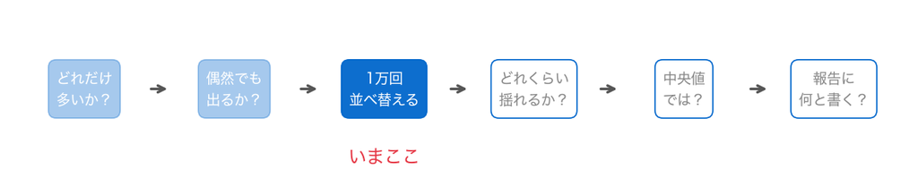

- 1回並べ替えると、差は小さくなった。けれども、1回では何とも言えない
- くじの引き直しを1万回くり返し、差がどう散らばるかを見る

## おさらい：forとappend

3節 ① ためる●○○○○○

```python
out = []
for k in range(3):
    out.append(k * 10)
print(out)
```

```
[0, 10, 20]
```

- 空のリストを作り、`for`の中で`append`すると、結果を1つずつためられる（第4回）

## お手本：1万回並べ替える

3節 ① ためる●●○○○○

```python
rng = np.random.default_rng(0)
perm = []
for r in range(10000):
    s = rng.permutation(t)
    perm.append(y[s == 1].mean() - y[s == 0].mean())
perm = np.array(perm)
print(len(perm))
print(perm[:3].round(1))
```

## ブロックで読む

3節 ① ためる●●●○○○

- 入力：年収`y`とラベル`t`
- くり返す中身：TODO①の2行（並べ替える → 差を出す）を、`append`でためる
- 出力：1万個の差の配列`perm`

## 1行ずつ読む

3節 ① ためる●●●●○○

- `rng = np.random.default_rng(0)`：セルの頭で、乱数生成器を作り直す
- `range(10000)`：1万回くり返す。`r`は回数を数えるだけで、中では使わない
- `np.array(perm)`：リストを、numpyの配列にする

## 1万個たまった

3節 ① ためる●●●●●○

```
10000
[-559.9  705.1  -58.4]
```

- 先頭の−559.9は、TODO①の差と同じ
- 同じシードから始めたので、1回目は同じ並べ替えになる

## なぜ、作り直すのか

3節 ① ためる●●●●●●

- TODO①で、すでに乱数を1回使った
- 作り直さないと、TODO①を何回実行したかで、このセルの結果が変わる
- 頭で作り直せば、いつ実行しても同じ1万個になる

## お手本：差の分布を描く

3節 ② 分布●○○○

```python
plt.hist(perm, bins=50)
plt.axvline(obs, color='red')
plt.xlabel('並べ替えたときの、平均の差（ドル）')
plt.ylabel('回数')
plt.show()
print(perm.mean().round(1), perm.std().round(1))
```

- `plt.axvline`：縦の線を引く。観測した差`obs`の位置に赤い線

## 赤い線は、どこにある？

3節 ② 分布●●○○

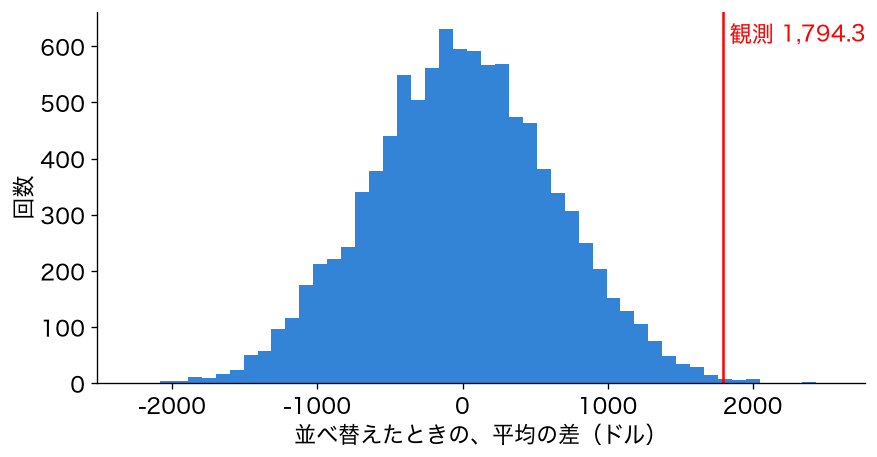

## 山は0のまわり

3節 ② 分布●●●○

```
-3.6 639.8
```

- 並べ替えたときの差の平均は−3.6ドル、標準偏差は639.8ドル
- 効果がなくても、±640ドルくらいの差は、偶然でよく出る

## 赤い線は、山の外

3節 ② 分布●●●●

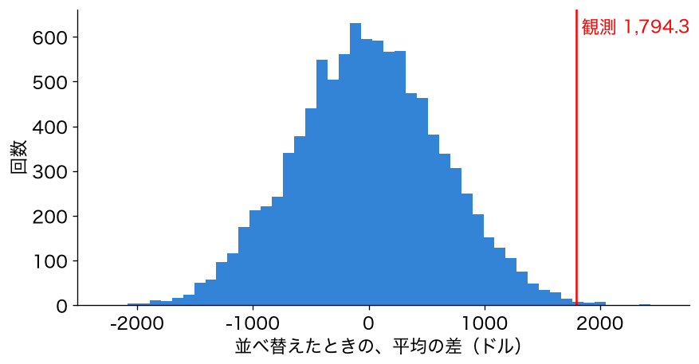

- 観測した1794.3ドルは、山の右の裾の、ずっと外にある
- 効果がないとしたら、これほどの差は、めったに出ない

## 「めったに」を、数にしたい

3節 ③ p値●○○○○

- 山の外にあることは、図で見えた
- どれくらい珍しいかを、数で表したい

## p値

3節 ③ p値●●○○○

- 帰無仮説が正しいとき、観測した差と同じか、それより極端な差が出る割合
- この割合を、p値と呼ぶ
- ここでは、並べ替えた差の大きさ（絶対値）が、観測した差の大きさ以上になった割合

## p値の式

3節 ③ p値●●●○○

$$p = \frac{|\text{並べ替えた差}| \ge |\text{観測した差}| \text{となった回数}}{10000}$$

- 分母は、並べ替えた回数（1万回）

## 両側を数える

3節 ③ p値●●●●○

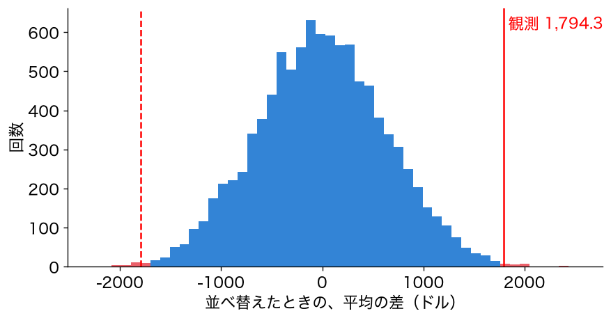

- 赤い線と点線の外側（両端）が、数える部分
- 訓練で年収が減る向きの、大きな差も数える

## p値の読み方

3節 ③ p値●●●●●

- p値が小さいほど、「効果がないのに、偶然でこれだけの差が出た」とは考えにくい
- よく使われる目安（有意水準）は0.05
- p値は、効果の大きさではない

## 新しい書き方：Trueの割合

3節 ④ 割合●○

```python
print(np.mean(np.array([True, False, True, True])))
print(np.abs(np.array([-3, 2])))
```

```
0.75
[3 2]
```

## 1行ずつ読む

3節 ④ 割合●●

- `np.mean`を真偽値に使うと、`True`を1、`False`を0として平均する
- つまり、`True`の割合。4つのうち3つで0.75
- `np.abs`：絶対値。−3は3に、2は2のまま

## TODO②：p値を出す

3節 ⑤ p値を出す●○○○○○

```python
# TODO: p値を出す
# ヒント: big = np.abs(perm) >= abs(obs)
#         print(big.sum())
#         p = np.mean(big)
#         print(p)
...
```

- 並べ替えた差の絶対値が、観測した差の絶対値以上になった回数と割合

## やってみよう：3節とTODO②

3節 ⑤ p値を出す●●○○○○

- 3節のお手本を上から実行する
- TODO②で、p値を出す

動画の人は、ここで一時停止。

## 答え合わせ：TODO②

3節 ⑤ p値を出す●●●○○○

```python
big = np.abs(perm) >= abs(obs)
print(big.sum())
p = np.mean(big)
print(p)
```

```
45
0.0045
```

## 1万回のうち45回

3節 ⑤ p値を出す●●●●○○

- 並べ替えた差が1794.3ドル以上に開いたのは、1万回のうち45回
- p値は0.0045
- 効果がないとしたら、こんなに大きな差は、1万回に45回しか出ない

## 偶然では、説明しにくい

3節 ⑤ p値を出す●●●●●○

- p値0.0045は、目安の0.05よりずっと小さい
- 差1794.3ドルは、偶然では説明しにくい

## まだ分からないこと

3節 ⑤ p値を出す●●●●●●

- p値で分かるのは、「偶然で出るか」まで
- 訓練の効果がどれくらいなのかは、まだ分からない

# 4. 差は、どれくらいの幅で揺れるか？

## 効果は、どれくらい？

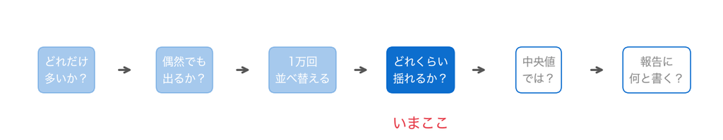

- 差は、偶然では出にくいことが分かった。では、効果はどれくらいか

## 1794.3ドルは、1回の値

4節 ① 考え方●○○○○○

- 1794.3ドルは、たまたまこの445人が集まったときの値
- 別の445人を集めて実験し直したら、差は変わるはず
- 実験し直したときに、差がどれくらい揺れるかを知りたい

## 実験は、やり直せない

4節 ① 考え方●●○○○○

- 実験をやり直すことはできない
- そこで、手元の185人を、訓練を受けた人全体の代わりとみなす
- その185人の中から、集め直す

## 復元抽出

4節 ① 考え方●●●○○○

- 185人の中から、1人ずつくじで選んでは戻す。これを185回くり返す
- 同じ人が2回以上選ばれることも、1回も選ばれないこともある
- このような選び方を、復元抽出と呼ぶ

## ブートストラップ

4節 ① 考え方●●●●○○

- 受けなかった260人からも、同じように260人を復元抽出する
- 平均の差を出すことを何回もくり返し、差の揺れを見る
- この方法を、ブートストラップと呼ぶ

## 5人で描く

4節 ① 考え方●●●●●○

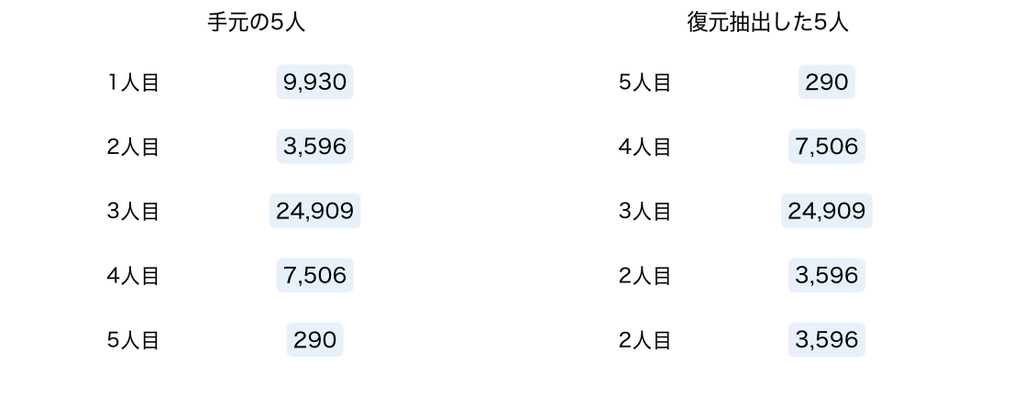

- 左は、訓練を受けた人の先頭の5人。右は、そこから5人を復元抽出したもの

## 同じ人が、何回も

4節 ① 考え方●●●●●●

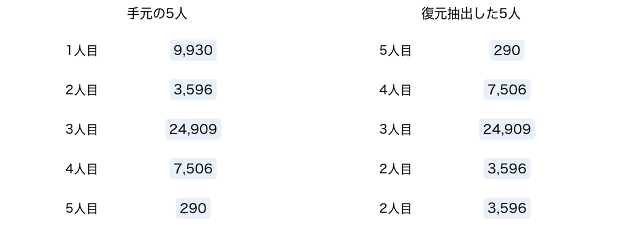

- 同じ人が何回か選ばれ、選ばれない人もいる
- 人数は5人のまま

## 新しい書き方：復元抽出

4節 ② choice●

```python
rng = np.random.default_rng(0)
print(rng.choice([10, 20, 30, 40, 50], 5))
```

```
[50 40 30 20 20]
```

- `rng.choice(並び, 個数)`：並びから、戻しながら指定した個数を選ぶ
- 20が2回出て、10は選ばれなかった

## お手本：1回ぶん

4節 ③ 1回ぶん●○○

```python
y1 = y[t == 1]
y0 = y[t == 0]
rng = np.random.default_rng(0)
a = rng.choice(y1, len(y1))
b = rng.choice(y0, len(y0))
print(round(a.mean() - b.mean(), 1))
```

## 1行ずつ読む

4節 ③ 1回ぶん●●○

- `y1`：訓練を受けた185人の年収。`y0`：受けなかった260人の年収
- `rng.choice(y1, len(y1))`：185人から、185人を復元抽出する
- 群ごとに、元と同じ人数を選ぶ

## 集め直すと、1522.1ドル

4節 ③ 1回ぶん●●●

```
1522.1
```

- 集め直した445人では、差は1794.3ドルではなくなった
- これを1万回くり返す

## お手本：1万回くり返す

4節 ④ 1万回●○○○○

```python
rng = np.random.default_rng(0)
boot = []
for r in range(10000):
    a = rng.choice(y1, len(y1))
    b = rng.choice(y0, len(y0))
    boot.append(a.mean() - b.mean())
boot = np.array(boot)
plt.hist(boot, bins=50)
plt.axvline(obs, color='red')
plt.xlabel('集め直したときの、平均の差（ドル）')
plt.ylabel('回数')
plt.show()
print(boot.mean().round(1), boot.std().round(1))
```

## ブロックで読む

4節 ④ 1万回●●○○○

- 入力：`y1`と`y0`
- くり返す中身：1回ぶんの3行（集め直す → 差を出す）を、`append`でためる
- 出力：1万個の差の配列`boot`と、ヒストグラム

## 3節のセルと、同じ形

4節 ④ 1万回●●●○○

- 空のリスト → `for`で1万回 → `append` → `np.array`
- 違うのは、くり返す中身だけ
- 並べ替え（`permutation`）が、集め直し（`choice`）に変わった

## 山は、どこにできた？

4節 ④ 1万回●●●●○

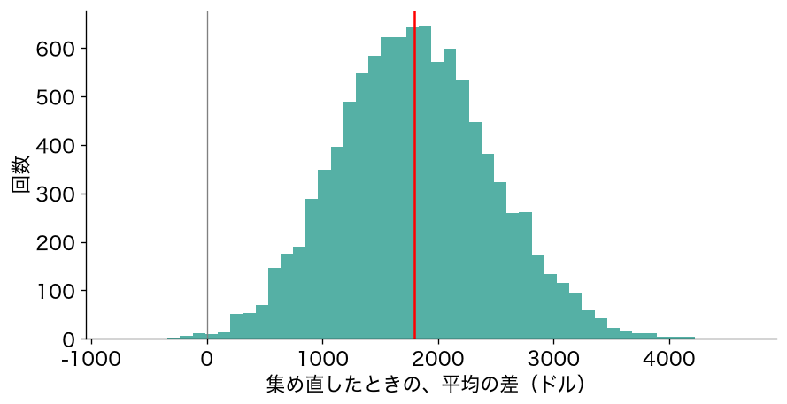

## 山は、観測した差のまわり

4節 ④ 1万回●●●●●

```
1800.2 670.0
```

- 差の平均は1800.2ドルで、観測した1794.3ドルに近い
- 標準偏差は670.0ドル。集め直すたびに、差はこれくらい揺れる

## 2つの山は、違う場所

4節 ⑤ 2つの山●○

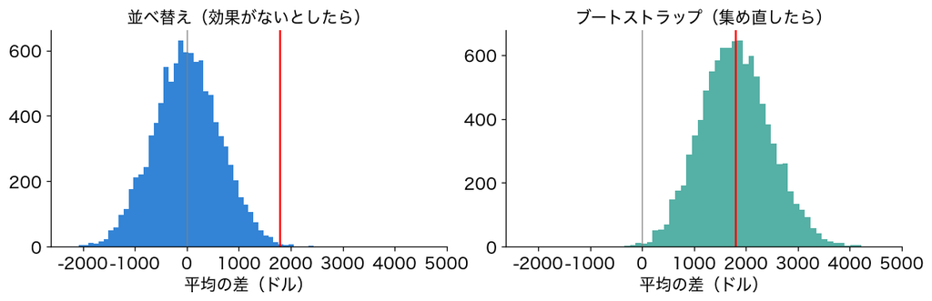

- 並べ替えの山は0のまわり、ブートストラップの山は1794.3ドルのまわり

## 作っている世界が違う

4節 ⑤ 2つの山●●

- 並べ替え：「効果がないとしたら」の世界。だから山は0のまわり
- ブートストラップ：「手元のデータが表す世界から、集め直したら」。山は観測した差のまわり
- 問いが違うので、使う道具も違う

## 幅を、数で表したい

4節 ⑥ 95%区間●○○

- 差が、どれくらいの範囲で揺れるかを、2つの数で表したい
- 1万個の差の、真ん中の大部分が入る範囲を使う

## 95%区間

4節 ⑥ 95%区間●●○

- 1万個の差を小さい順に並べ、下から2.5%と上から2.5%を切り落とす
- 残った真ん中の95%の範囲を、95%ブートストラップ区間と呼ぶ
- 信頼区間の作り方の1つ（パーセンタイル法）

## 新しい書き方：パーセンタイル

4節 ⑥ 95%区間●●●

```python
print(np.percentile([10, 20, 30, 40, 50], [0, 50, 100]))
```

```
[10. 30. 50.]
```

- `np.percentile(配列, q)`：小さい順に並べて、下からq%の位置の値
- `q`にリストを渡すと、まとめて返す。50パーセンタイルは中央値

## TODO③：95%区間を出す

4節 ⑦ 区間を出す●○○○○○

```python
# TODO: 平均の差の95%区間を出す
# ヒント: print(np.percentile(boot, [2.5, 97.5]).round(1))
...
```

- `boot`の2.5パーセンタイルと97.5パーセンタイル

## やってみよう：4節とTODO③

4節 ⑦ 区間を出す●●○○○○

- 4節のお手本を上から実行する
- TODO③で、平均の差の95%区間を出す

動画の人は、ここで一時停止。

## 答え合わせ：TODO③

4節 ⑦ 区間を出す●●●○○○

```python
print(np.percentile(boot, [2.5, 97.5]).round(1))
```

```
[ 550.9 3162.4]
```

- 95%区間は、550.9ドルから3162.4ドル

## 区間を、図に重ねる

4節 ⑦ 区間を出す●●●●○○

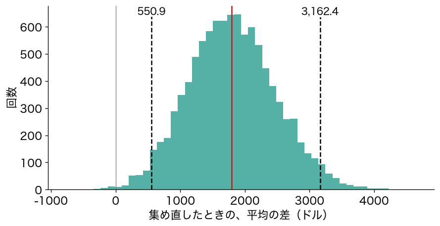

- 黒い点線のあいだに、1万個の差の95%が入る

## 区間は、0を含まない

4節 ⑦ 区間を出す●●●●●○

- 区間の下限は550.9ドルで、0より大きい
- 集め直しても、差はほとんどプラスのまま
- 差はプラスと言えそう

## けれども、区間は広い

4節 ⑦ 区間を出す●●●●●●

- 訓練の効果は、年に約550ドルかもしれない
- 3000ドルを超えるかもしれない
- p値が0.0045と小さくても、効果の大きさは、これだけの幅でしか分からない

# 5. 中央値で比べると、どうなるか？

## 平均は、引っぱられる

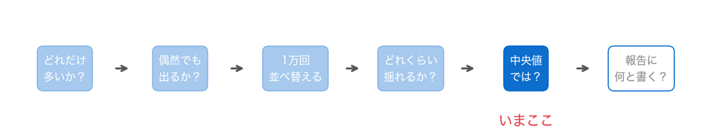

- 平均の差の幅が分かった。けれども、年収は右に長く裾を引いていた
- 平均は、少数の年収の高い人に引っぱられる

## お手本：年収の高い人

5節 ① 高い人●○○

```python
print(np.sort(y1)[-3:].round(0))
print(round(np.median(y1) - np.median(y0), 1))
```

- `np.sort`：小さい順に並べる。`[-3:]`：うしろから3つ
- 2行目は、2つの群の中央値の差

## 3万ドルを超える人が3人

5節 ① 高い人●●○

```
[34099. 36647. 60308.]
1093.5
```

- 訓練を受けた人には、年収が3万ドルを超える人が3人いる
- 中央値の差は1093.5ドルで、平均の差の1794.3ドルより小さい

## 中央値の差も、揺れる

5節 ① 高い人●●●

- 中央値の差1093.5ドルも、集め直せば揺れる
- 中央値の差でも、ブートストラップで95%区間を出したい

## 同じことを、2回目

5節 ② 関数に●○○○

- 4節のくり返しのセルを写して、`mean`を`median`に書き換えればできる
- けれども、同じ手順を写すのは、これで2回目
- 同じ手順を2回目に使いたくなったので、関数にまとめる

## 違うのは、統計量だけ

5節 ② 関数に●●○○

- 4節のセルで、平均を出しているのは`a.mean()`と`b.mean()`だけ
- そこを「平均でも中央値でも入れられる穴」にしたい
- 穴に入れるのは、関数（`np.mean`や`np.median`）

## 新しい書き方：関数を値として渡す

5節 ② 関数に●●●○

```python
f = np.median
print(f([1, 2, 10]))
f = np.mean
print(f([1, 2, 10]))
```

```
2.0
4.333333333333333
```

- 関数は、変数に入れられる。`f(...)`は、入れた関数と同じ働きをする

## 平均は、10に引っぱられる

5節 ② 関数に●●●●

- `[1, 2, 10]`の中央値は2、平均は約4.33
- 1つだけ大きい10に、平均が引っぱられた
- 年収の平均にも、同じことが起きている

## お手本：関数にまとめる

5節 ③ boot_diff●○

```python
def boot_diff(stat):
    rng = np.random.default_rng(0)
    out = []
    for r in range(10000):
        a = rng.choice(y1, len(y1))
        b = rng.choice(y0, len(y0))
        out.append(stat(a) - stat(b))
    return np.array(out)
```

## 4節のセルとの違い

5節 ③ boot_diff●●

- 4節の`a.mean()`を`stat(a)`に、`b.mean()`を`stat(b)`に書き換えた
- 全体を`def boot_diff(stat):`の中に入れ、最後に`return`で返す
- 入力：統計量の関数`stat`。出力：1万個の差の配列

## 4節と、同じになる？

5節 ④ 確かめる●○

```python
bm = boot_diff(np.mean)
print(np.allclose(bm, boot))
```

- `np.mean`を渡せば、4節の`boot`と同じになるはず
- `np.allclose`：2つの配列がほぼ同じか（第11回）

## 同じ1万個

5節 ④ 確かめる●●

```
True
```

- 同じシードから、同じ順に乱数を使うので、4節と同じ1万個の差になった
- 関数にまとめても、手順は変わっていない

## TODO④：中央値の差の95%区間

5節 ⑤ 中央値の区間●○○○○○

```python
# TODO: 中央値の差の95%区間を出す
# ヒント: bmed = boot_diff(np.median)
#         print(np.percentile(bmed, [2.5, 97.5]).round(1))
...
```

- `boot_diff`に`np.median`を渡すだけ

## やってみよう：5節とTODO④

5節 ⑤ 中央値の区間●●○○○○

- 5節のお手本を上から実行する
- TODO④で、中央値の差の95%区間を出す

動画の人は、ここで一時停止。

## 答え合わせ：TODO④

5節 ⑤ 中央値の区間●●●○○○

```python
bmed = boot_diff(np.median)
print(np.percentile(bmed, [2.5, 97.5]).round(1))
```

```
[-444.7 3019.7]
```

## 区間が、0をまたぐ？

5節 ⑤ 中央値の区間●●●●○○

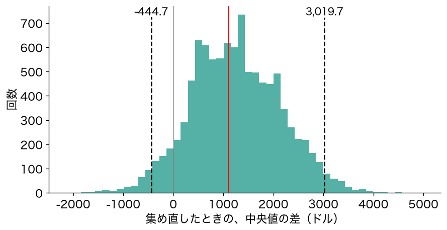

## 中央値では、言い切れない

5節 ⑤ 中央値の区間●●●●●○

- 中央値の差の95%区間は、−444.7ドルから3019.7ドル
- 区間が0を含む
- 中央値で比べると、受けた人の年収が多いとは言い切れない

## 山が、でこぼこ

5節 ⑤ 中央値の区間●●●●●●

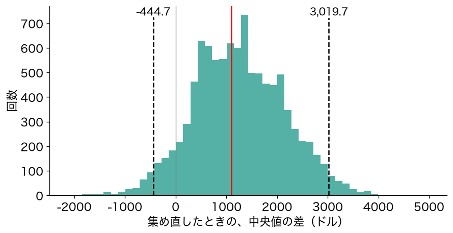

- 中央値は、真ん中あたりの数人の年収で決まる
- そのため、集め直したときの値が、飛び飛びになる

## なぜ、結論が変わるのか

5節 ⑥ なぜ●○

- 平均の差には、2つのことが効いている
- 1つは、収入の無い人が減ったこと（35.4%から24.3%）
- もう1つは、年収の高い人が何人かいること

## 中央値は、動かされにくい

5節 ⑥ なぜ●●

- 中央値は、0ドルの人の数や、年収の高い人に動かされにくい
- そのため、訓練による違いが、ぼやけて見える
- どちらの物差しで測ったかを、報告に書く必要がある

# 6. 報告に、何と書くか？

## 物差しで、言えることが違う

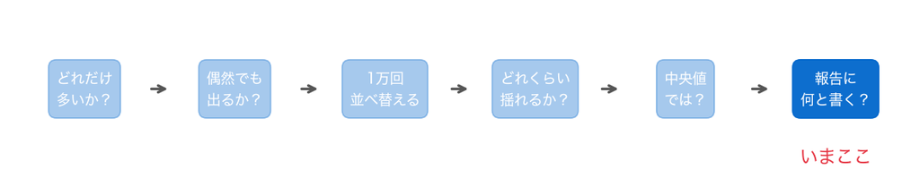

- 平均と中央値で、言えることが違った
- 2つの物差しの結果を1つの表にまとめて、報告に何と書くかを決める

## おさらい：辞書のリストを表に

6節 ① 表にする●○○○○

```python
rows = [{'名前': 'A', '値': 1}, {'名前': 'B', '値': 2}]
pd.DataFrame(rows)
```

```
  名前  値
0  A  1
1  B  2
```

- 辞書が1行ぶん。キーが列の名前になる（第4回）

## お手本：2つの物差しを1つの表に

6節 ① 表にする●●○○○

```python
rows = []
for name, stat in [('平均', np.mean), ('中央値', np.median)]:
    lo, hi = np.percentile(boot_diff(stat), [2.5, 97.5])
    rows.append({'物差し': name, '差': stat(y1) - stat(y0),
                 '下限': lo, '上限': hi})
pd.DataFrame(rows).round(1)
```

## 1行ずつ読む

6節 ① 表にする●●●○○

- `for name, stat in [...]`：名前と関数の組を1つずつ取り出し、2つの変数に分ける
- `lo, hi = ...`：2つの値（下限と上限）を、2つの変数に分けて受け取る
- 1回のくり返しで、辞書を1行ぶん`rows`にためる

## 並べると、違いが見える

6節 ① 表にする●●●●○

```
   物差し       差     下限      上限
0   平均  1794.3  550.9  3162.4
1  中央値  1093.5 -444.7  3019.7
```

- 平均の区間は0を含まず、中央値の区間は0を含む

## 図で並べる

6節 ① 表にする●●●●●

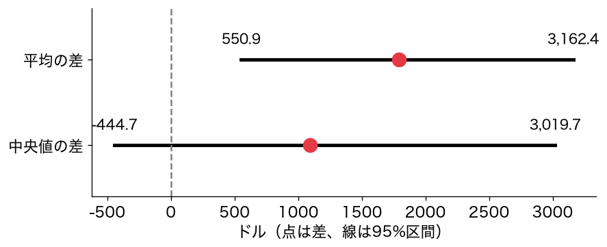

- 点が差、線が95%区間。灰色の点線が0

## 答え：偶然では説明しにくい

6節 ② 答え●○○○

- 訓練を受けた人の年収は、平均で1794.3ドル多い
- ラベルを1万回並べ替えると、これ以上の差が出たのは45回。p値は0.0045

## 答え：効果の大きさには幅がある

6節 ② 答え●●○○

- ブートストラップの95%区間は、550.9ドルから3162.4ドル
- 効果はプラスと言えそうだが、大きさは幅をもってしか分からない

## 答え：中央値では言い切れない

6節 ② 答え●●●○

- 中央値の差は1093.5ドルで、95%区間は−444.7ドルから3019.7ドル
- 0を含むので、中央値で比べると、差があるとは言い切れない

## 報告の文

6節 ② 答え●●●●

訓練を受けた人の年収は、平均で約1800ドル多く、偶然では説明しにくい。ただし効果の大きさは年に約550ドルから3200ドルの幅があり、中央値で比べると差があるとは言い切れない。

## まだ言えないこと①：誰に効いたか

6節 ③ まだ言えないこと●○

- 445人をまとめて比べた
- 高校を卒業していない人など、一部の人に限ると、言えることが変わるかもしれない

## まだ言えないこと②：時と場所

6節 ③ まだ言えないこと●●

- 分かるのは、1978年の1年だけ
- 1970年代のアメリカで、参加を希望した人の結果である

# まとめ

## 今日の道筋を振り返る

⑥ 振り返る●○○○○○

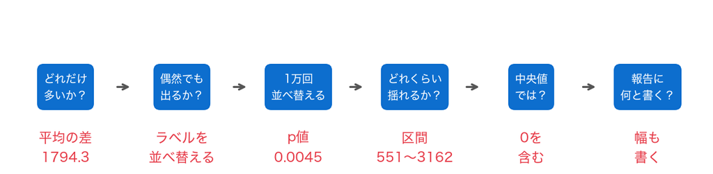

- 6つの小さな問いに答えて、訓練の効果を報告の文にした

## 今日の歩み

⑥ 振り返る●●○○○○

差を出す → 並べ替えて偶然と比べる → 集め直して幅を見る → 中央値でも → 報告の文

## 今日持ち帰る1文

⑥ 振り返る●●●○○○

差が偶然でも出るかは、ラベルを並べ替えて確かめる（並べ替え検定）。差がどれくらいの幅で揺れるかは、行を復元抽出して確かめる（ブートストラップ）。どちらも、くり返した結果をためて分布として読む。

## 今日の要点①：並べ替え検定

⑥ 振り返る●●●●○○

- 帰無仮説（効果はない）のもとでは、ラベルを並べ替えても年収は変わらない
- 並べ替えた差の分布の外に、観測した差があれば、偶然では説明しにくい
- p値は「偶然で、これ以上の差が出る割合」で、効果の大きさではない

## 今日の要点②：ブートストラップ

⑥ 振り返る●●●●●○

- 群ごとに、同じ人数を復元抽出し、差を何回も出す
- 真ん中の95%の範囲（95%区間）で、効果の大きさの幅を示す
- 右に裾を引く分布では、平均と中央値で結論が変わることがある

## 今日の要点③：Python

⑥ 振り返る●●●●●●

- `np.random.default_rng(シード)`、`rng.permutation`・`rng.choice`
- くり返しの結果をリストにためて`np.array`。`np.mean(条件)`で割合、`np.percentile`で区間
- 同じ手順を2回目に使うときは、関数を引数で渡す`def`にまとめる

## 課題の出し方

⑦ このあと●○○○

- ノートの最後の「課題（提出）」に取り組む
- 応用②の答えと応用③の文章を、LACSに入力して提出（＝出席。期限なし）
- AIを使ってもよい。何を聞いて、どう直したかを1行書く

## 次回予告：区分の表

⑦ このあと●●○○

- 今日は、数の列（年収）を、2つの群で比べた
- データには、年代やジャンルのように、区分で表される列もよくある

## 次回の問い

⑦ このあと●●●○

行と列が両方とも区分の表を、どうやって1枚の地図にするか？

## このあと：課題へ

⑦ このあと●●●●

ノートの「課題（提出）」へ。高校を卒業していない人に限って、同じ問いに答えます。

# ここから先は解答

## 課題のあとで見る

課題（提出）に取り組んでから見てください。動画の人は、ここで一時停止。

## 応用①：高卒資格なしに限る

```python
dn = d[d['高卒資格なし'] == 1]
yn = dn['年収78'].to_numpy()
tn = dn['訓練'].to_numpy()
print(len(dn))
print(dn['訓練'].value_counts())
obs_n = yn[tn == 1].mean() - yn[tn == 0].mean()
print(round(obs_n, 1))
rng = np.random.default_rng(0)
perm_n = []
for r in range(10000):
    s = rng.permutation(tn)
    perm_n.append(yn[s == 1].mean() - yn[s == 0].mean())
perm_n = np.array(perm_n)
print(np.mean(np.abs(perm_n) >= abs(obs_n)))
```

## 348人で、差は1154.0ドル

```
348
訓練
0    217
1    131
1154.0
0.0965
```

- 受けた人131人、受けなかった人217人。差は1154.0ドルに縮んだ
- p値は0.0965で、目安の0.05より大きい

## 偶然でも出る範囲

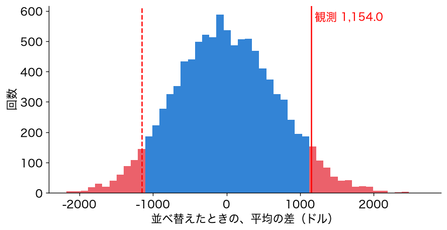

- 観測した差は、並べ替えた山の裾の中にある

## 応用②：区間の下限

```python
y1n = yn[tn == 1]
y0n = yn[tn == 0]
rng = np.random.default_rng(0)
boot_n = []
for r in range(10000):
    a = rng.choice(y1n, len(y1n))
    b = rng.choice(y0n, len(y0n))
    boot_n.append(a.mean() - b.mean())
ci = np.percentile(boot_n, [2.5, 97.5]).round(1)
print(ci)
print('答え:', ci[0])
```

## 下限は−245.0ドル

```
[-245.  2675.9]
答え: -245.0
```

- 95%区間は、−245.0ドルから2675.9ドル
- 区間が0を含む

## 効かなかった、とも言えない

- 人数を絞ると、差の揺れが大きくなる
- 「効いたとは言い切れない」は、「効かなかった」とは違う
- この人たちに効くかを確かめるには、もっと多くの人で調べる

## 応用③：模範例

くじ引きで訓練の有無を決めた445人では、訓練を受けた人の1978年の年収は平均で1794.3ドル多く、並べ替え検定のp値は0.0045で、偶然では説明しにくい差でした。ただし、95%区間は550.9ドルから3162.4ドルと幅が広く、効果の大きさははっきりしません。高校を卒業していない348人に限ると、差は1154.0ドルに縮み、p値は0.0965、95%区間も−245.0ドルから2675.9ドルで0を含むので、この人たちに効いたとは言い切れません。ただし、効かなかったとも言えず、もっと多くの人で調べる必要があります。

## 書き方の型

- 1文目：全体の差と、p値（偶然で出るか）
- 2文目：区間（効果の大きさの幅）
- 3文目：一部の人に限った結果と、言えないこと

# 発展（任意）

## Kは、人が決めた

- 第11回では、142か国を、平均寿命と対数GDPで3つのグループに分けた
- グループの数$K=3$は、人が決めた
- 慣性は$K$を増やすほど必ず下がるので、慣性では$K$を選べない

## 構造のないデータと比べる

- 今日の並べ替え検定と同じ考え方を使う
- グループの構造がまったく無いデータ（参照データ）を、乱数で何組も作る
- 同じ$K$で分けたときの慣性を、本物のデータと比べる

## Gap統計

$$\mathrm{Gap}(K) = \overline{\log W^{*}_K} - \log W_K$$

- $W_K$は、$K$個に分けたときの慣性。$\overline{\log W^{*}_K}$は、参照データの$\log W_K$の平均
- 本物の慣性が参照データよりずっと小さければ、偶然では出ない構造がある
- Tibshiraniほか（2001）の方法

## 参照データの作り方

- 標準化した2列の、最小値から最大値までの長方形を考える
- その中に、一様な乱数で142個の点をまく
- これを50組作る

## お手本：142か国を準備する

```python
from sklearn.preprocessing import StandardScaler
from sklearn.cluster import KMeans
gm = pd.read_csv(f'{DATA_DIR}/gapminder.csv')
g7 = gm[gm['year'] == 2007].reset_index(drop=True)
g7['対数GDP'] = np.log10(g7['gdpPercap'])
X = StandardScaler().fit_transform(g7[['lifeExp', '対数GDP']])
print(X.shape)
```

- 第11回と同じ、標準化した142行2列の`X`

## お手本：KごとにGapを出す

```python
def logW(Z, k):
    km = KMeans(n_clusters=k, n_init=10, random_state=0).fit(Z)
    return np.log(km.inertia_)

rng = np.random.default_rng(0)
lo, hi = X.min(axis=0), X.max(axis=0)
refs = [rng.uniform(lo, hi, X.shape) for b in range(50)]
gap, se = {}, {}
for k in range(1, 9):
    ref_logW = np.array([logW(R, k) for R in refs])
    gap[k] = ref_logW.mean() - logW(X, k)
    se[k] = ref_logW.std() * np.sqrt(1 + 1 / 50)
pd.DataFrame({'Gap': gap, '標準誤差': se}).round(3)
```

## 1行ずつ読む

- `rng.uniform(下限, 上限, 大きさ)`：一様な乱数。参照データを1組作る
- 参照データの組と$K$の、二重のくり返し。結果は辞書`gap`と`se`にためる
- 標準誤差は、参照データの$\log W_K$の標準偏差に$\sqrt{1 + 1/50}$を掛けたもの

## KごとのGap

```
     Gap   標準誤差
1  0.126  0.054
2  0.802  0.059
3  0.772  0.059
4  0.750  0.051
5  0.906  0.054
6  0.970  0.054
7  0.965  0.047
8  0.958  0.050
```

- $K=1$のGapは0.126で、とても小さい

## 1標準誤差の規則

$$\mathrm{Gap}(K) \ge \mathrm{Gap}(K+1) - \mathrm{se}(K+1)$$

- これを満たす、いちばん小さい$K$を選ぶ
- $K$を1つ増やしても、Gapが標準誤差の分より大きくは増えないなら、そこで止める

## 規則が選ぶのはK＝2

```
選ぶK: 2
```

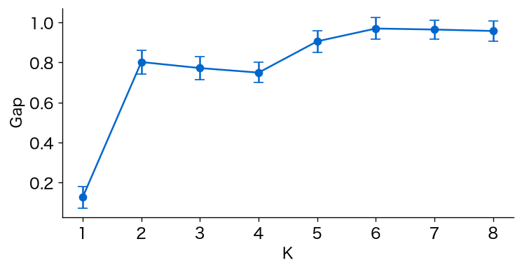

## K＝1は、退けられる

- 分けない$K=1$は、規則で退けられる
- 142か国には、一様なデータでは出ない、まとまりがある

## K＝3は、規則では選ばれない

- 規則が選ぶのは$K=2$。第11回の$K=3$は選ばれない
- ただし、$K=2$と$K=3$のGapの差は、標準誤差より小さい
- Gapがいちばん大きいのは、$K=6$

## 試すなら

- 参照データの組を50から20に減らして、選ぶ$K$が変わるかを見る
- 報告に使う$K$は、規則の答えと、目的（方針をいくつに分けたいか）をあわせて決める

## おわり

- 今日は、ラベルを並べ替えて、差が偶然でも出るかを確かめた
- 行を集め直して、差がどれくらいの幅で揺れるかを確かめた